# Classification of Acute Respiratory Distress Syndrome

Robert Edwards

Removing features that are not relevant to this analysis

Selecting only rows with data.

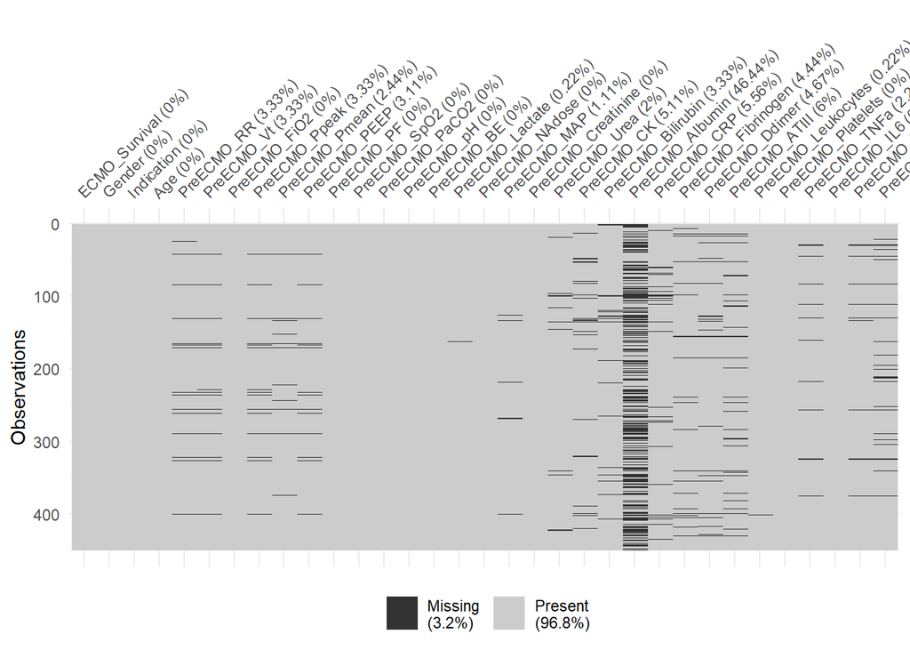

An upset plot from the `UpSetR` package can be used to visualise the patterns of missingness, or rather the combinations of missingness across cases. To see combinations of missingness and intersections of missingness amongst variables, use the `gg_miss_upset` function:

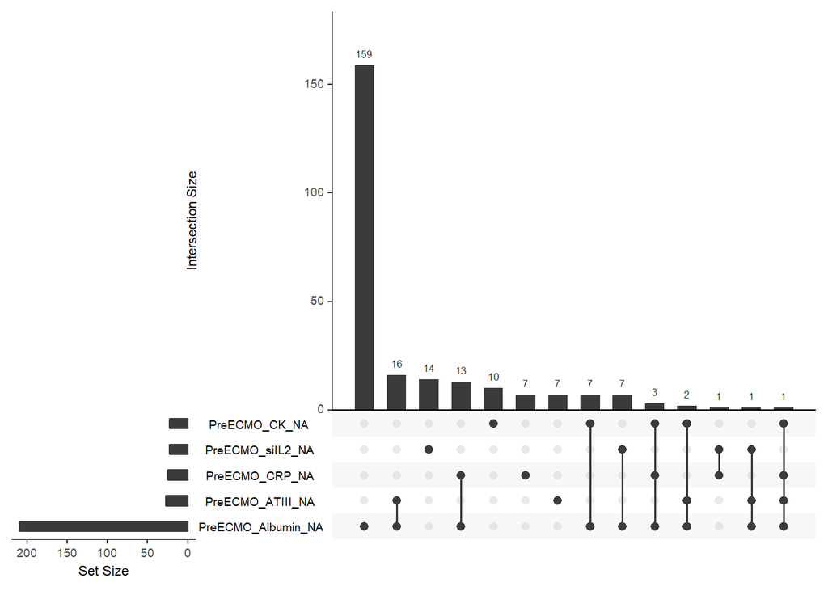

If there are 40 intersections, there will be up to 40 combinations of variables explored. The number of sets and intersections can be changed by passing arguments `nsets = 10` to look at 10 sets of variables, and nintersects = 50 to look at 50 intersections.

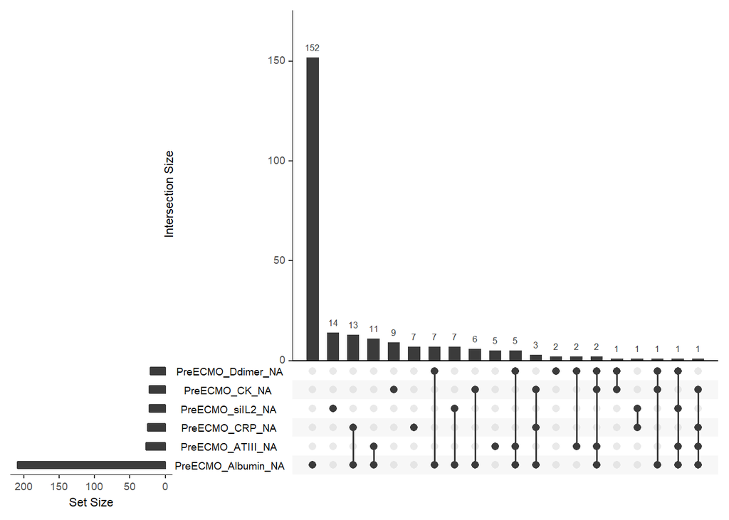

This plot shows the number of missing values in each variable in a dataset. It is powered by the `miss_var_summary()` function.

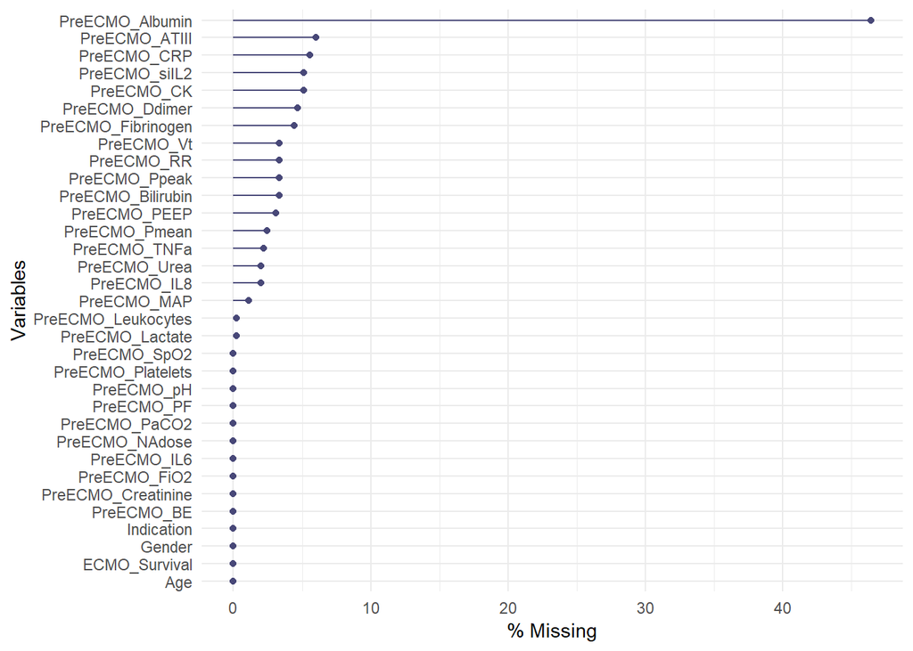

This plot shows the number of missings in each column, broken down by a categorical variable from the dataset. It is powered by a `dplyr::group_by` statement followed by `miss_var_summary()`.

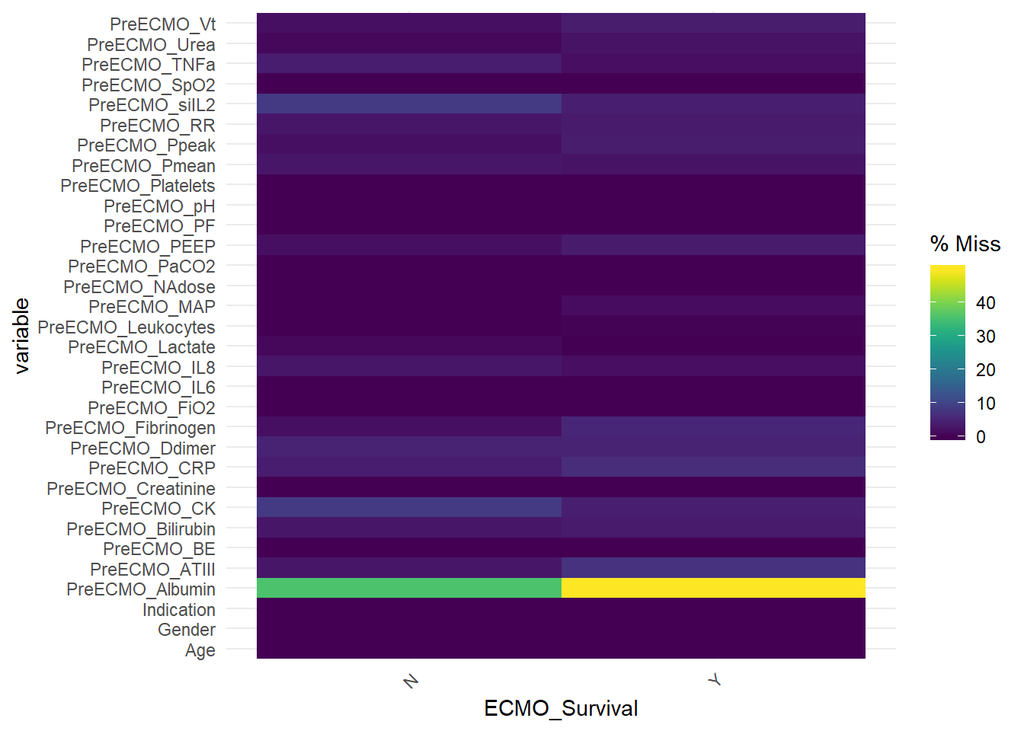

This plot shows the cumulative sum of missing values, reading the rows of the dataset from the top to bottom. It is powered by the `miss_case_cumsum()` function.

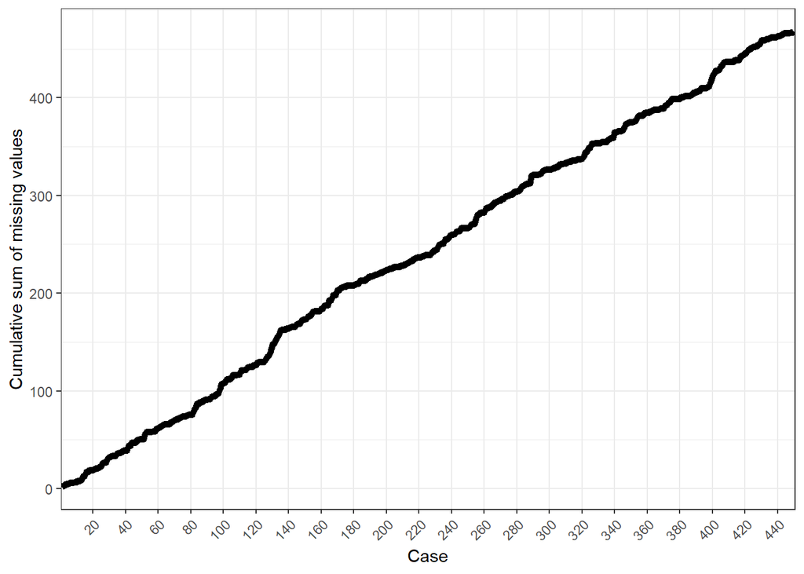

This plot shows the cumulative sum of missing values, reading columns from the left to the right of your dataframe. It is powered by the `miss_var_cumsum()` function.

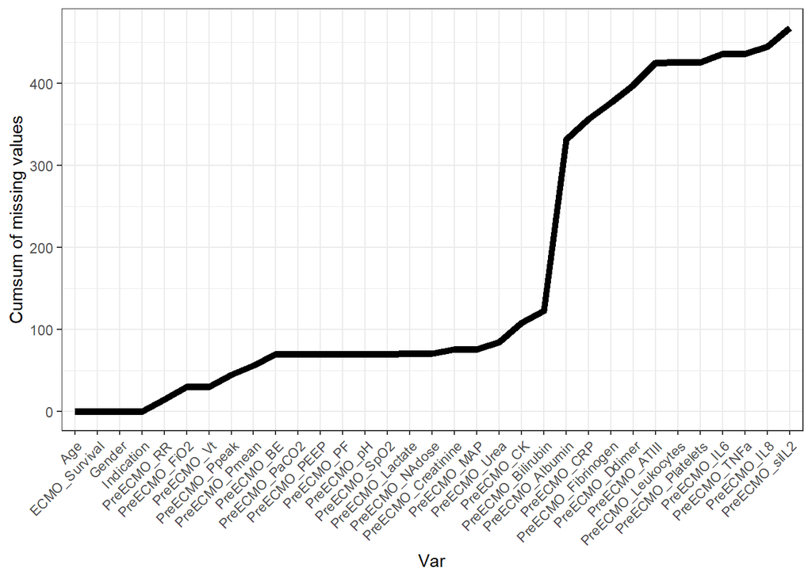

# Exploratory Data Analysis

We first visually explore the data to get a sense of the features and distributions of the data. Then we will conduct hypothesis tests for each feature based on `ECMO_Survival` as a rough idea how relevant each feature will be.

## Boxplot

All continuous features are normally scaled to be comparable.

```
Observations: 450
Variables: 30
$ Age                <dbl> <matrix[25 x 1]>
$ PreECMO_RR         <dbl> <matrix[25 x 1]>
$ PreECMO_Vt         <dbl> <matrix[25 x 1]>
$ PreECMO_FiO2       <dbl> <matrix[25 x 1]>
$ PreECMO_Ppeak      <dbl> <matrix[25 x 1]>
$ PreECMO_Pmean      <dbl> <matrix[25 x 1]>
$ PreECMO_PEEP       <dbl> <matrix[25 x 1]>
$ PreECMO_PF         <dbl> <matrix[25 x 1]>
$ PreECMO_SpO2       <dbl> <matrix[25 x 1]>
$ PreECMO_PaCO2      <dbl> <matrix[25 x 1]>
$ PreECMO_pH         <dbl> <matrix[25 x 1]>
$ PreECMO_BE         <dbl> <matrix[25 x 1]>
$ PreECMO_Lactate    <dbl> <matrix[25 x 1]>
```

[output cut: 17 more lines]

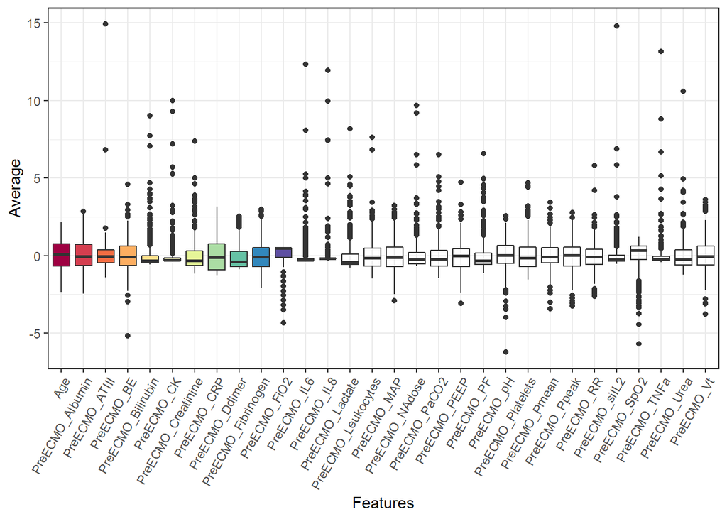

The boxplot shows many highly skewed variables indicating that these likely need to be transformed in some fashion (likely log transformation). For **logistic regression**, first a model will be fit without transformations and then the not significant variables will be transformed and model fit will be evaluated.